# Web Scraping with R

Fabian Gülzau

28 March 2018

## Introduction

> “If programming is magic, then *web scraping* is wizardry.” (Mitchell 2015: vii)

The goal of my presentation is to turn you into capable magicians and sorceresses. We can use R as our magical wand and the following spells:

- Common packages: rvest and RSelenium
- Helpful tools: [Selector Gadget](http://selectorgadget.com/) and Developer Tools
- The [tidyverse](https://www.tidyverse.org/)

## Web scraping

- Not a well defined task
- No definition in Munzert et al. (2015) or Mitchell (2015)
- Harsh learning curve (leads to copy&paste)

But:

[figure not shown]

## A roadmap

Getting data from the web often involves the following steps:

1. Finding a suitable data source
2. Locating the element(s) we are interested in on the web page
3. Download the data
4. ????
5. PROFIT!!!!

In the following, I will guide you through the steps by considering a real-world example.

## A case study: Inequality in the Bundesliga

Inequality of market values between German soccer teams:

- Data: [Transfermarkt](https://www.transfermarkt.de/)
- Tools: `rvest`, `tidyverse` (and `RSelenium`)
- Similar [analysis](https://towardsdatascience.com/inequality-in-the-premier-league-a3a9a7294d96) for the Premier League; Soccer Leagues as winner-takes-it-all markets ([Lutter 2013](http://www.mpifg.de/people/lm/downloads/MPIfG_13-14_11_Lutter.pdf))

## Step 1: Finding data

The first step involves the identification of a suitable data source. Fortunately, the web site “Transfermarkt” provides information on the market values of German soccer teams since [season 2005/2006](https://www.transfermarkt.de/1-bundesliga/startseite/wettbewerb/L1/plus/?saison_id=2005).

```r
# Save URL
url <- "https://www.transfermarkt.de/1-bundesliga/startseite/wettbewerb/L1"
```

We could now go on and copy&paste the information together using another army of defenseless student assistants. However, we want to avoid this kind of torture by leveraging the architecture of the web (Step 2).

## Step 2: Identify elements

On a basic level browsers interpret documents which are written in the **H**yper**T**ext **M**arkup **L**anguage. Every element has a specific tag that we can use to locate it on a web page.

- [Selector Gadget](http://selectorgadget.com/)
- Developer Tools
- Learn to understand [HTML](https://www.w3schools.com/html/) and [CSS](https://flukeout.github.io/)

```r
# Load package
library(tidyverse); library(rvest)

# Select element
node <- read_html(url) %>%
  html_nodes(css = "#yw1 > table:nth-child(2)")
```

Further important topics: **D**ocument **O**bject **M**odel ([DOM](https://en.wikipedia.org/wiki/Document_Object_Model)) and Cascading Style Sheets ([CSS](https://en.wikipedia.org/wiki/Cascading_Style_Sheets)) (Munzert et al. 2015).

## Step 3. Downloading the data

In a final step, we have to download the information. `rvest` provides two function for this purpose:

- `html_table` for html tables
- `html_text` for text

The node at hand is a table, which can be accessed in the following way:

```r
# Getting the table
table <- node %>%
  html_table(fill = TRUE) %>% # Get the table
  .[[1]] %>%                  # Get rid of the first layer
  glimpse()                   # Have a look at the result
```

```
## Observations: 19
## Variables: 11
## $ Verein          <lgl> NA, NA, NA, NA, NA, NA, NA, NA, NA, NA, NA, NA...
## $ Verein          <chr> "", "FC Bayern München", "Borussia Dortmund", ...
## $ name            <chr> "", "Bayern München", "Bor. Dortmund", "RB Lei...
## $ name            <int> NA, 27, 28, 24, 23, 25, 27, 28, 27, 33, 27, 33...
## $ Kader           <chr> "500", "27,2", "25,6", "24,4", "25,2", "25,7",...
## $ `ø-Alter`       <chr> "25,5 Jahre", "14", "15", "17", "10", "17", "1...
## $ Legionäre       <chr> "264", "642,50 Mio. €", "364,45 Mio. €", "305,...
## $ Gesamtmarktwert <chr> "3,08 Mrd. €", "23,80 Mio. €", "13,02 Mio. €",...
## $ `ø-Marktwert`   <chr> "6,16 Mio. €", "642,50 Mio. €", "364,45 Mio. €...
## $ `Ges.-MW`       <chr> "3,08 Mrd. €", "23,80 Mio. €", "13,02 Mio. €",...
## $ `ø-MW`          <chr> "6,16 Mio. €", NA, NA, NA, NA, NA, NA, NA, NA,...
```

Note: rvest can also extract links with `html_attr("href")`.

## Data cleaning I

After some furious regexing:

[figure not shown]

## Data cleaning II

We eventually get a useful data set for the latest season:

```
## Observations: 18
## Variables: 7
## $ team       <chr> "FC Bayern München", "Borussia Dortmund", "RasenBal...
## $ team.abb   <chr> "Bayern München", "Bor. Dortmund", "RB Leipzig", "B...
## $ squad.size <int> 27, 28, 24, 23, 25, 27, 28, 27, 33, 27, 33, 25, 29,...
## $ age.mean   <chr> "27,2", "25,6", "24,4", "25,2", "25,7", "25,5", "24...
## $ foreign.no <chr> "14", "15", "17", "10", "17", "17", "17", "13", "15...
## $ mv.tot     <dbl> 642500000, 364450000, 305550000, 262900000, 2157000...
## $ mv.mean    <dbl> 23800000, 13020000, 12730000, 11430000, 8630000, 65...
```

## Market values of German soccer teams

The data can now easily be plotted with `ggplot2`:

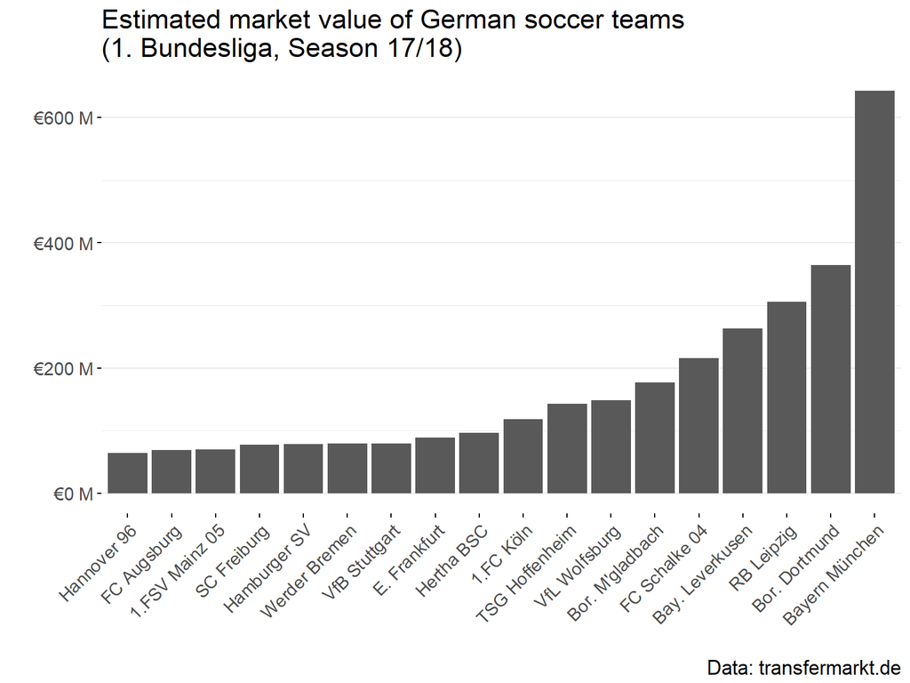

## Getting the information across seasons

- Data is hidden behind a drop-down button (JavaScript)
- However, inspection shows that URL is adjusted through the menu

-> Writing a loop

## Generalizing the approach

Generalizing involves two steps:

1. Wrapping our approach for a single target into a function
2. Using `for`, `apply` or `purrr::map` to loop through pages

## Application: Generalizing the approach

We need:

1. A vector of URLs to loop over
2. One function that scrapes the content
3. One function that cleans the data

Firstly, we construct a vector that holds the URLs:

```r
pages <- vector(mode = "character", length = 13) # Container
years <- seq(2005, 2017, 1)                      # "Dynamic element"

# Bring URL (static) and year (dynamic) together
for (i in seq_along(years)) {
  pages[[i]] <- paste0("https://www.transfermarkt.de/1-bundesliga/startseite/wettbewerb/L1/plus/?saison_id=", years[i])
}
```

Secondly, we wrap our former approach into a function:

```r
# Wrap the code that worked for a single page into a function (scraper)
transfer_scraper <- function(x) {
  table <- read_html(x) %>%
    html_nodes(css = "#yw1 > table:nth-child(2)") %>%
    html_table(fill = TRUE, header = TRUE) %>%
    .[[1]]
}
```

Thirdly, the data cleaning should also be automated with a function:

```r
clean_fun <- function(x) {
  # (1) Remove unused columns/rows
  table <- x[,c(-1, -9:-11)]
  table <- table[-1,]

  # (2) Rename columns
  colnames(table) <- c("team", "team.abb", "squad.size", "age.mean", "foreign.no", "mv.tot", "mv.mean")

  # (b) Apply the function
  table <- table %>%
    mutate_at(vars(mv.tot, mv.mean), mil_to_num)
}
```

## Map over web sites

Using the `map` function, we can apply our functions to the URLs.

```r
# Basically, very short for-loops:
# (1) Scrape transfermarkt.de
multi <- map(pages, ~transfer_scraper(.))

# (2) Clean the data
multi.clean <- map(multi, ~clean_fun(.))
```

## Result

The result is a list of data frames:

```
## List of 13
##  $ :'data.frame':    18 obs. of  7 variables:
##  $ :'data.frame':    18 obs. of  7 variables:
##  $ :'data.frame':    18 obs. of  7 variables:
##  $ :'data.frame':    18 obs. of  7 variables:
##  $ :'data.frame':    18 obs. of  7 variables:
##  $ :'data.frame':    18 obs. of  7 variables:
##  $ :'data.frame':    18 obs. of  7 variables:
##  $ :'data.frame':    18 obs. of  7 variables:
##  $ :'data.frame':    18 obs. of  7 variables:
##  $ :'data.frame':    18 obs. of  7 variables:
##  $ :'data.frame':    18 obs. of  7 variables:
##  $ :'data.frame':    18 obs. of  7 variables:
##  $ :'data.frame':    18 obs. of  7 variables:
```

## Inequality in the German Bundesliga

Now, we can analyze the inequality among German Bundesliga teams from season 2005/2006 to 2017/2018:

```r
library(reldist)

# Create a table of Gini coefficients
gini.tbl <- tibble(
  gini = map_dbl(multi.clean, ~gini(.$mv.tot)),
  year = as.integer(years)
)

glimpse(gini.tbl)
```

```
## Observations: 13
## Variables: 2
## $ gini <dbl> 0.3172450, 0.3139587, 0.3425045, 0.3218549, 0.3130237, 0....
## $ year <int> 2005, 2006, 2007, 2008, 2009, 2010, 2011, 2012, 2013, 201...
```

## Visualize the inequality

A simple plot can be constructed with `ggplot2`:

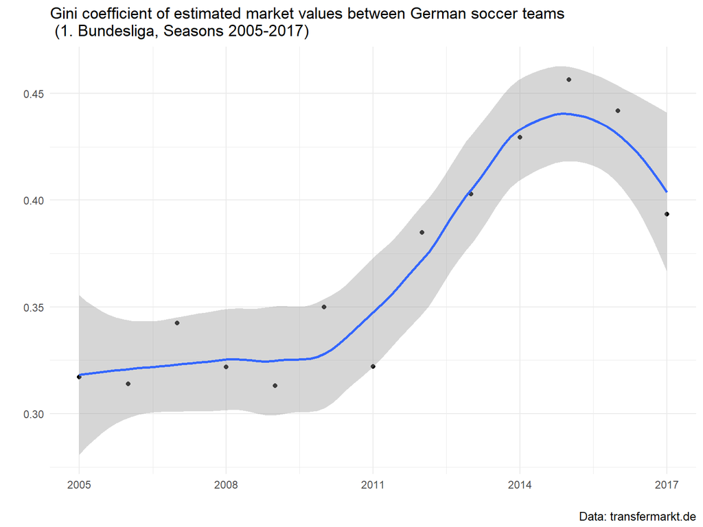

```r
# Plot the Gini coefficients
ggplot(data = gini.tbl, aes(x = year, y = gini)) +
  geom_point(stat = "identity") +
  geom_smooth(method = "loess") +
  scale_x_continuous(name = "", breaks = seq(2005, 2017, 3)) +
  labs(title = "Gini coefficient of estimated market values between German soccer teams\n (1. Bundesliga, Seasons 2005-2017)",
       y = "", caption = "Data: transfermarkt.de") +
  theme_minimal()
```

## Dealing with dynamic web sites (JavaScript)

Dynamic web sites:

- Use JavaScript to load data based on user requests
- We cannot send simple requests
- We have to deal with loading time

Solution:

- RSelenium
- splashr

## RSelenium

Basically, we just steer a browser from within R (Chrome, PhantomJS). The code snippet below shows how we can navigate Chrome to the FAZ archive and search for “Deutsches Institut für Wirtschaftsforschung”.

```r
library('RSelenium')
remDr <- RSelenium::rsDriver()
rD <- remDr[["client"]]

# Navigate to FAZ archive
rD$navigate("https://www.faz-biblionet.de/faz-portal")

# Identify the search box
search <- rD$findElement(using = "css selector", "#f_q")

#lick on the search button
search$clickElement()

# Send search terms
keys <- rD$sendKeysToActiveElement(list("Deutsches Institut für Wirtschaftsforschung"))

# Identify the search button and click it
search.button <- rD$findElement(using = "css", "#f_c0")

# Click
search.button$clickElement()
```

## Some notes

Please, keep in mind ([Ethics of Web Scraping](https://rud.is/b/2017/07/28/analyzing-wait-delay-settings-in-common-crawl-robots-txt-data-with-r/)):

- Use [**A**pplication **P**rogramming **I**nterfaces](https://www.programmableweb.com/apis/directory) whenever possible (ask for the data)
- Do not send too many requests at once ([DoS attack](https://www.programmableweb.com/apis/directory))
- `Sys.sleep(sample(seq(0,2,0.5), 1))` at the end of each loop

Learn to build proper loops and regex ([Wickham & Grolemund 2017](http://r4ds.had.co.nz/)).

## Bibliography

Lutter, M. (2013). The Winner Takes It all: Erfolgsungleichheiten auf Märkten. MPIfG Jahrbuch 2013-2014, 63-70.

Mitchell, Ryan (2015). Web Scraping with Python. Collecting Data from the Modern Web, Sebastopol: O’Reilly.

Munzert, S., Rubba, C., Meißner, P. & Nyhuis, D. (2015). Automated Data Collection with R. A Practical Guide to Web Scraping and Text Mining, Chichester: Wiley & Sons.

Wickham, H. & Grolemund, G. (2017). R for Data Science. Visualize, Model, Tidy, and Import Data, Sebastopol: O’Reilly.